# Film festival database 3rd dump impressions

19/11/2021

# Duration, Film table

Here and below unless noted: entries with NA YearOfProduction removed, impossible years and future removed. Plots with duplicates removed: duplicates in concatenation of TitleVA_YearOfProduction_Duration removed (preferring entries with fewer NAs and if equal then later upload date); then 50325 left. Plots with no duplicate removal: just the impossible years (upload date before the platform existed, film produced before film existed) filters.

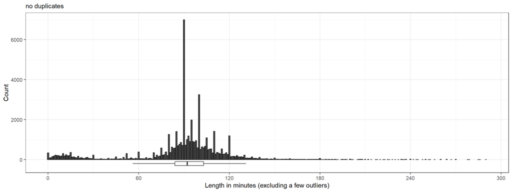

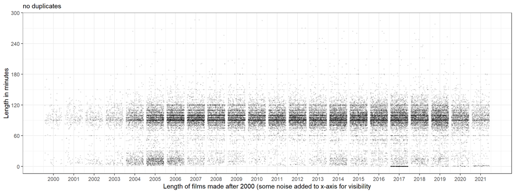

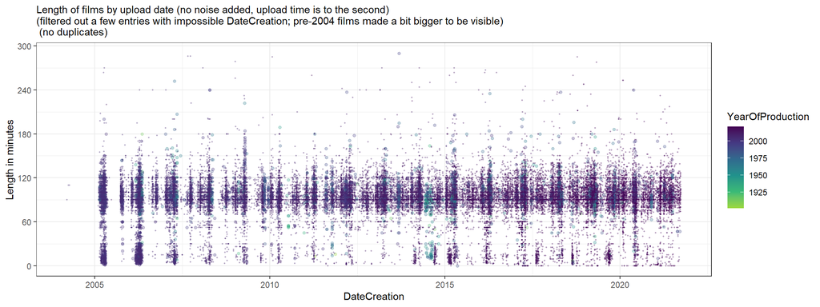

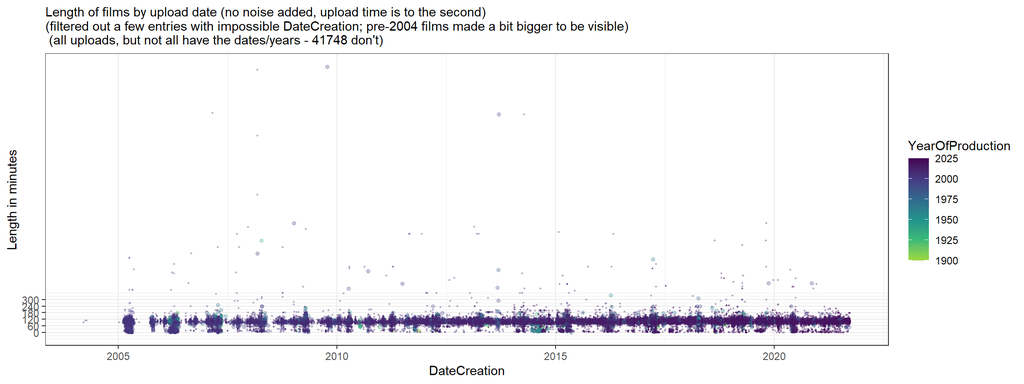

# Production year, Film table

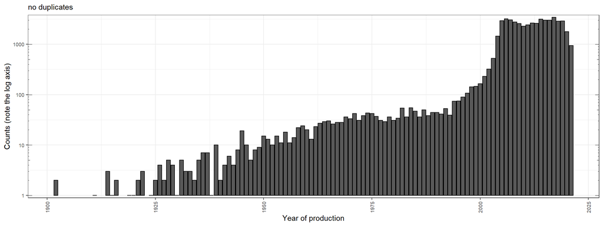

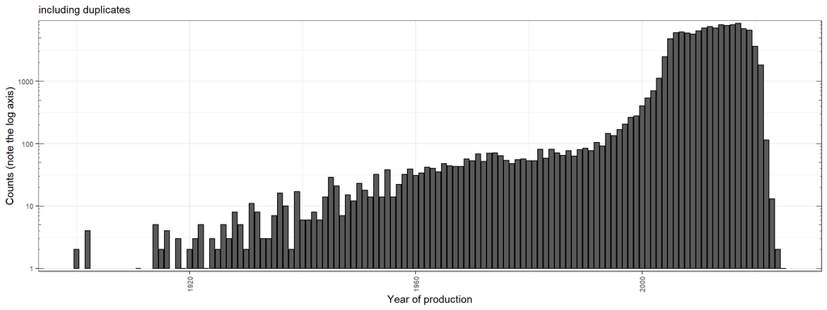

# Upload frequency and type

(still the same subset/filter as described above)

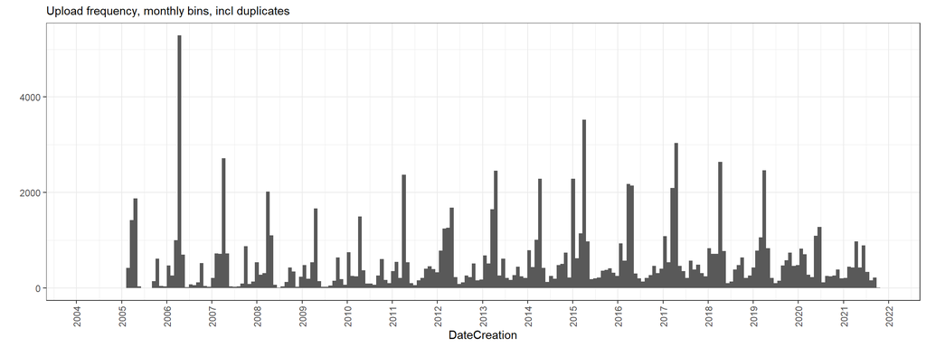

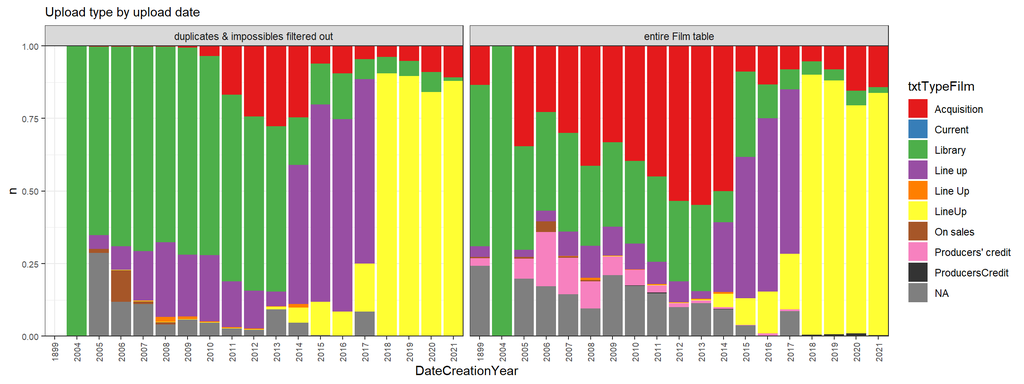

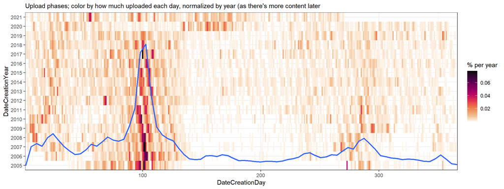

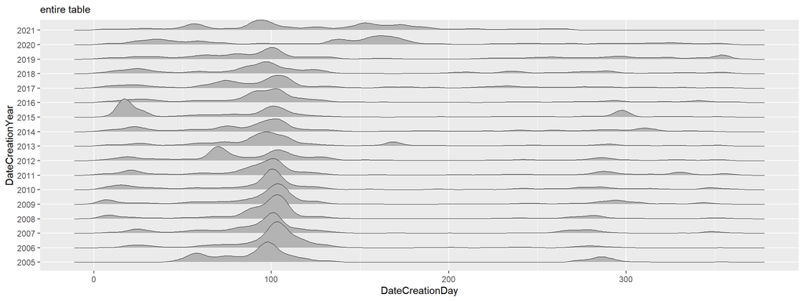

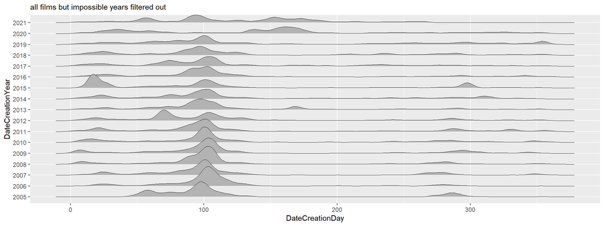

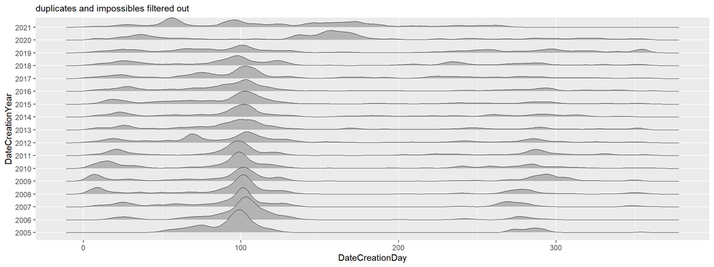

# Completeness

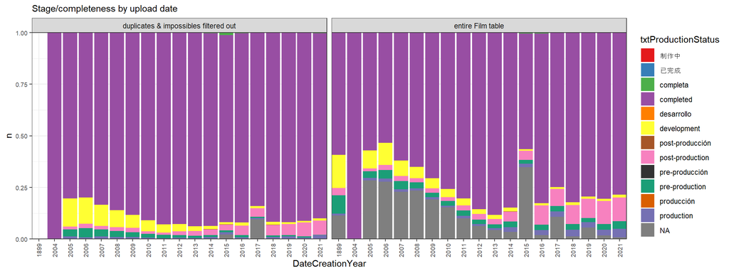

without normalization:

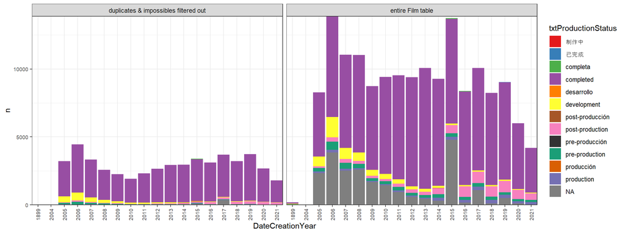

# Budget

the refMenu thing; again no duplicates etc as above, but prioritizing those with refMenu entry. Is 0 same as NA or literally 0?

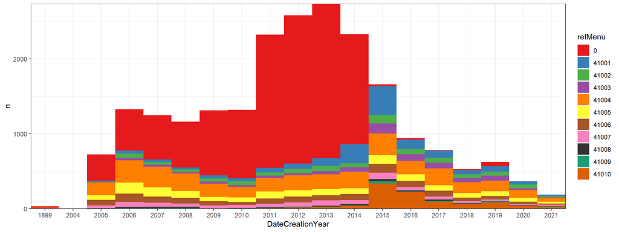

# Genre

The following plots: there’s sometimes multiple genres, languages, countries per film, I’m summing all of them below; so in principle a film with many labels can have a bit more effect on the summary than one with single tags.

I’m going to lowercase all the categories, as sometimes capitalization varies.

Filtering: there’s a bunch of refFilm IDs here that don’t occur in the Film table; 145828 compared to the full table; 204137 after filtering out duplicates and films with impossible date or length as discussed above. I’m going to filter out what I’m assuming are the duplicates (not in terms of what appears here multiple times i.e. multi-genre, but what appears in the Film table as multiple times) in this and the following sections. For the idxFilmKind table, that entails keeping about 14% of the original table, but should provide a more objective view.

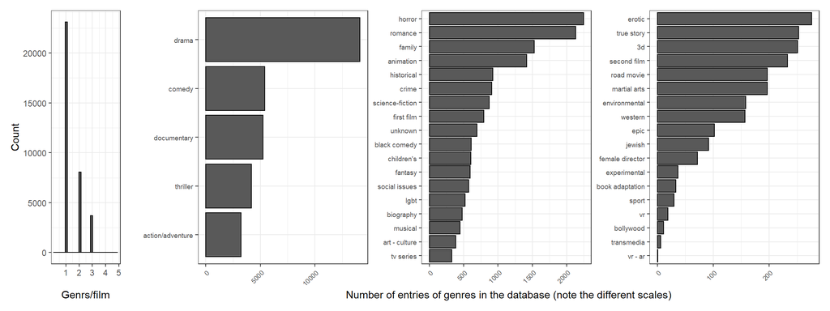

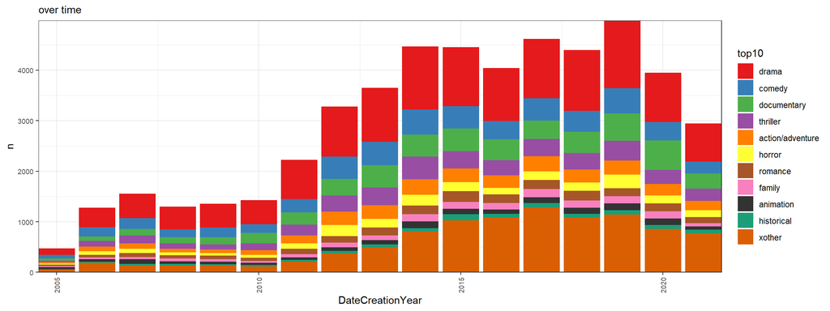

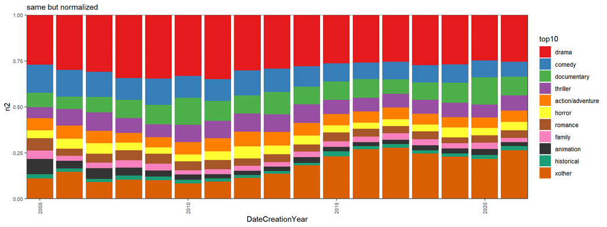

# Genre without duplicate removal

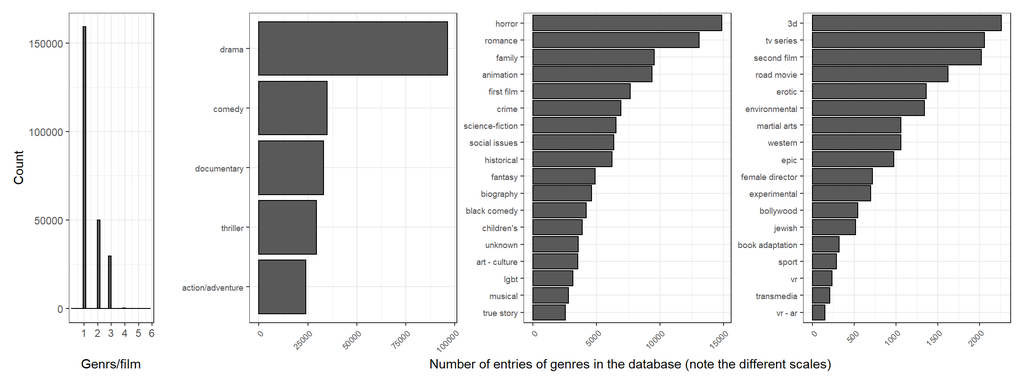

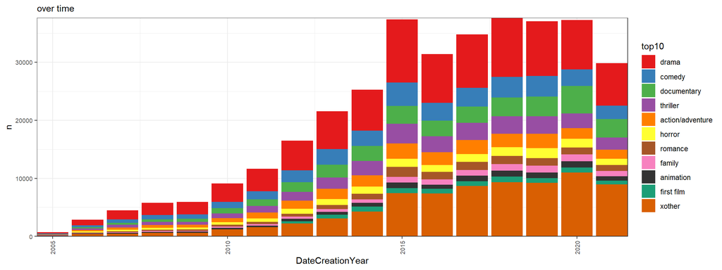

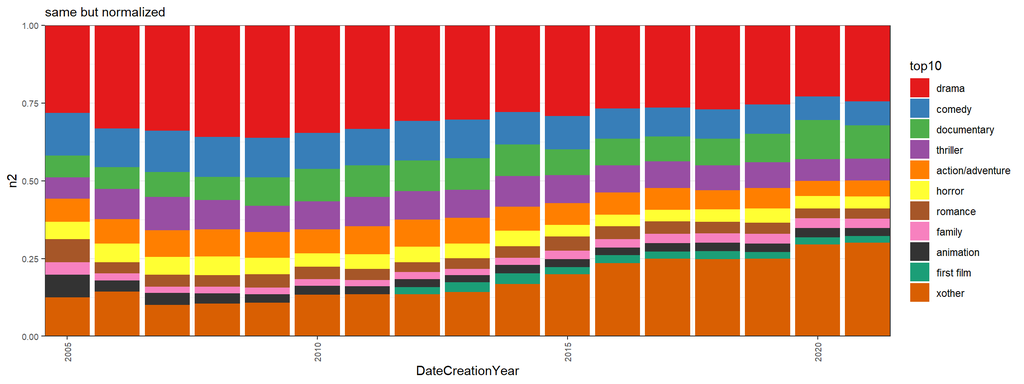

# Language

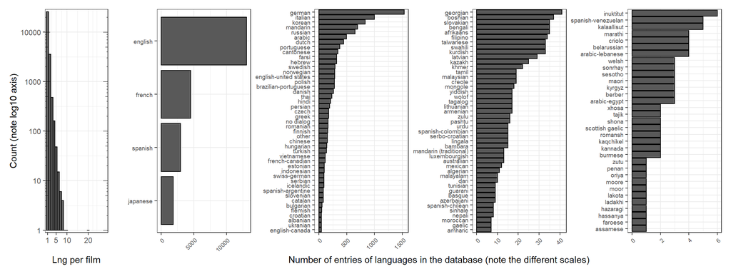

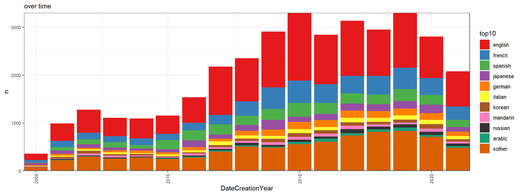

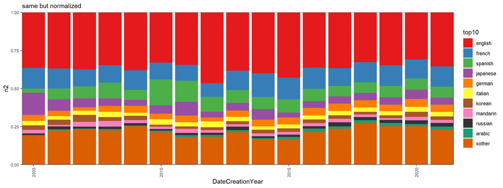

# Language without duplicate removal

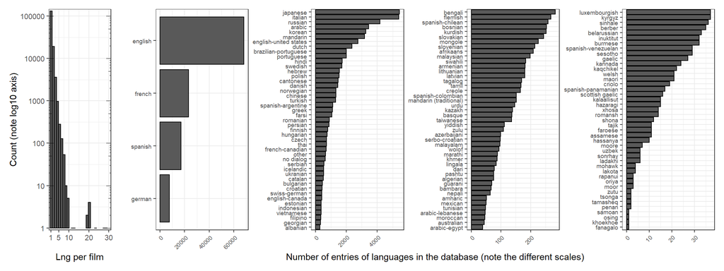

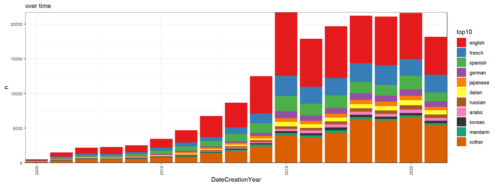

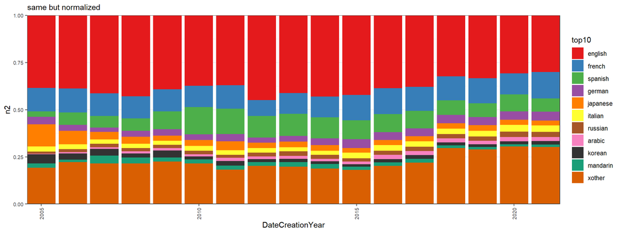

# Country of origin

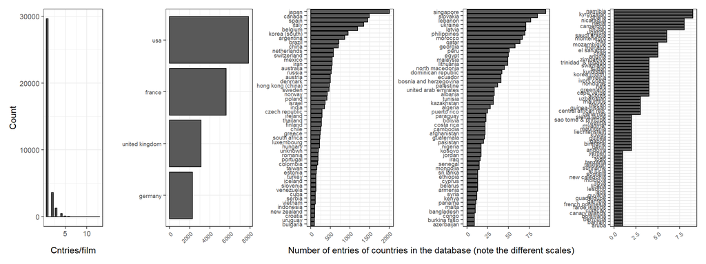

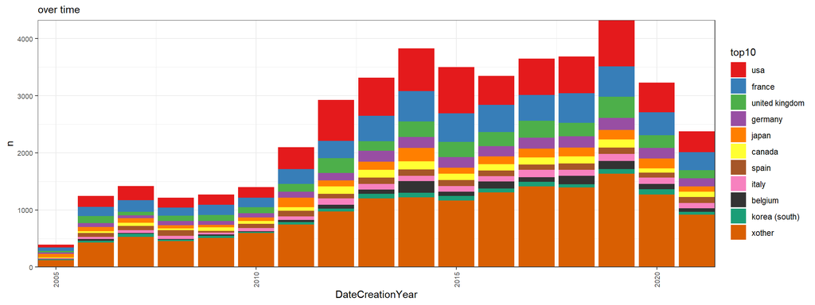

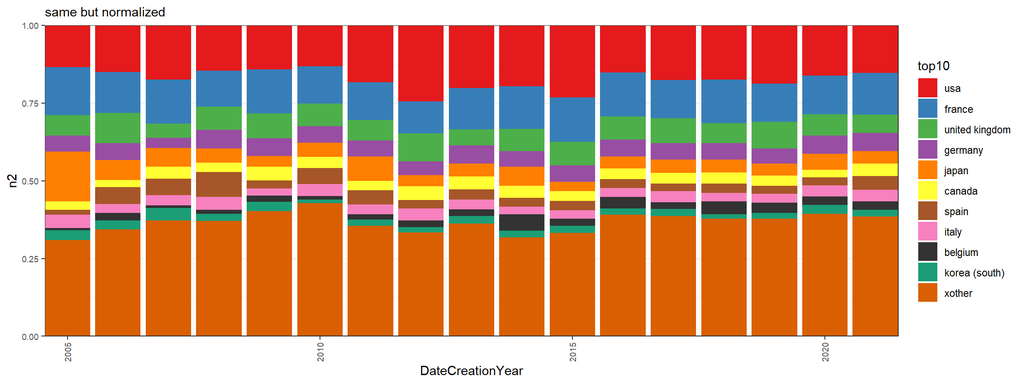